# Ch 11 exercises

For each of the examples below, you should follow the sequence we’ve used previously:

1. What is the biological question?
2. Is the predictor continuous or categorical?
3. Write out the linear model corresponding to this question.
4. What distribution do you expect the response variable to follow?
5. What are the assumptions behind the statistical model you’ll fit?
   1. Are those assumptions satisfied?
6. Fit the model
   1. How will you assess whether the model fits well?
   2. Can you detect an effect of the predictor?
   3. How do you measure the effect?
7. What do you conclude (including any cautions)

## A.

Li et al. (2015) investigated ways of revegetating damaged freshwater enviroments with vegetation. They used a sweet of 4 plant species, and focused on the combined effects of propagule pressure (i.e., the initial seeding event) and water depth on the aquatic vegetation that developed. They reported data for each plant species separately and considered overall plant “community”, putting all species together.

The four plant species can propagate clonally, by shoot regeneration, and they used shoot fragments to “seed” experimental pots. Each pot had 1, 2, or 4 fragments of each of the four species (i.e. there were three propagule pressures). The pots, filled with natural lake sediment, were placed in larger plastic tanks, which were filled to a depth of 30 or 70 cm. There were 5 tanks for each depth. The tanks were outside in full sun, and plants were allowed to grow for 7 weeks, after which time plants were harvested and measured.

For each species in a pot, five shoots were selected and their length measured, the number of nodes (indicating clonal growth) counted, and dry biomass calculated. The total biomass for that species was also measured and used to estimate total nodes and total shoot length. Values for each species were then used to calulate total biomass, total shoot length, and total number of nodes for that pot.

Their data can be found in Table S1 of the paper, but we’ve extracted the data and renamed some of the columns to make things clearer. Our file is here.

```r
df <-read.csv("data/li.csv")
set_sum_contrasts()
```

```
setting contr.sum globally: options(contrasts=c('contr.sum', 'contr.poly'))
```

```r
head(df, 10)
```

|  | depth | tank | pressure | biomass | nodes | slength | hvbiomass |
| --- | --- | --- | --- | --- | --- | --- | --- |
| 1 | 30 | 1 | low | 3.204 | 1161.9653 | 14.095498 | 2.606 |
| 2 | 30 | 1 | medium | 3.523 | 1456.9005 | 16.637120 | 2.496 |
| 3 | 30 | 1 | high | 7.077 | 1679.0204 | 19.736082 | 5.690 |
| 4 | 30 | 2 | low | 3.969 | 1257.9132 | 15.239968 | 2.789 |
| 5 | 30 | 2 | medium | 4.470 | 1402.1528 | 20.200615 | 3.609 |
| 6 | 30 | 2 | high | 8.041 | 2172.3806 | 28.823652 | 5.935 |
| 7 | 30 | 3 | low | 0.530 | 371.1823 | 4.193746 | 0.339 |
| 8 | 30 | 3 | medium | 1.473 | 756.2558 | 8.357996 | 1.019 |
| 9 | 30 | 3 | high | 1.719 | 1191.0750 | 15.192225 | 1.532 |
| 10 | 30 | 4 | low | 1.879 | 814.2920 | 10.042774 | 1.521 |

```r
df$depth<-as.factor(df$depth)
df$tank<-as.factor(df$tank)
```

### How do propagule pressure and water depth address these three measures of the plant community?

**Remember to go through the steps at the start of these exercises to make sure you have identified the design and assumptions clearly**

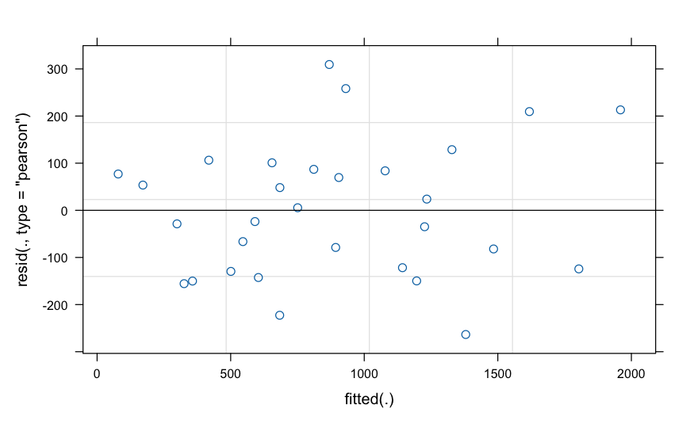

```r
#Can use aov or linear mixed models to do this
nodes.lmer <-lmer(nodes~depth + pressure + depth*pressure + (1|tank), REML=TRUE, df)
plot(nodes.lmer)
```

```r
summary(nodes.lmer, ddf="Kenward-Roger")
```

```
Linear mixed model fit by REML. t-tests use Kenward-Roger's method ['lmerModLmerTest']
Formula: nodes ~ depth + pressure + depth * pressure + (1 | tank)
   Data: df

REML criterion at convergence: 354.1

Scaled residuals:
     Min       1Q   Median       3Q      Max
-1.40672 -0.66015 -0.04919  0.46002  1.65145

Random effects:
 Groups   Name        Variance Std.Dev.
 tank     (Intercept) 81944    286.3
 Residual             35085    187.3
Number of obs: 30, groups:  tank, 10

Fixed effects:
                 Estimate Std. Error      df t value Pr(>|t|)
(Intercept)        884.15      96.77    8.00   9.137 1.66e-05 ***
depth1             313.09      96.77    8.00   3.236    0.012 *
pressure1          329.60      48.36   16.00   6.815 4.15e-06 ***
pressure2         -288.98      48.36   16.00  -5.975 1.94e-05 ***
depth1:pressure1    70.48      48.36   16.00   1.457    0.164
depth1:pressure2   -36.08      48.36   16.00  -0.746    0.467
---
Signif. codes:  0 ‘***’ 0.001 ‘**’ 0.01 ‘*’ 0.05 ‘.’ 0.1 ‘ ’ 1

Correlation of Fixed Effects:
            (Intr) depth1 prssr1 prssr2 dpt1:1
depth1       0.000
pressure1    0.000  0.000
pressure2    0.000  0.000 -0.500
dpth1:prss1  0.000  0.000  0.000  0.000
dpth1:prss2  0.000  0.000  0.000  0.000 -0.500
```

```r
anova (nodes.lmer, ddf="Kenward-Roger")
```

```
Type III Analysis of Variance Table with Kenward-Roger's method
                Sum Sq Mean Sq NumDF DenDF F value    Pr(>F)
depth           367295  367295     1     8 10.4687   0.01196 *
pressure       1937927  968963     2    16 27.6176 6.477e-06 ***
depth:pressure   74527   37263     2    16  1.0621   0.36889
---
Signif. codes:  0 ‘***’ 0.001 ‘**’ 0.01 ‘*’ 0.05 ‘.’ 0.1 ‘ ’ 1
```

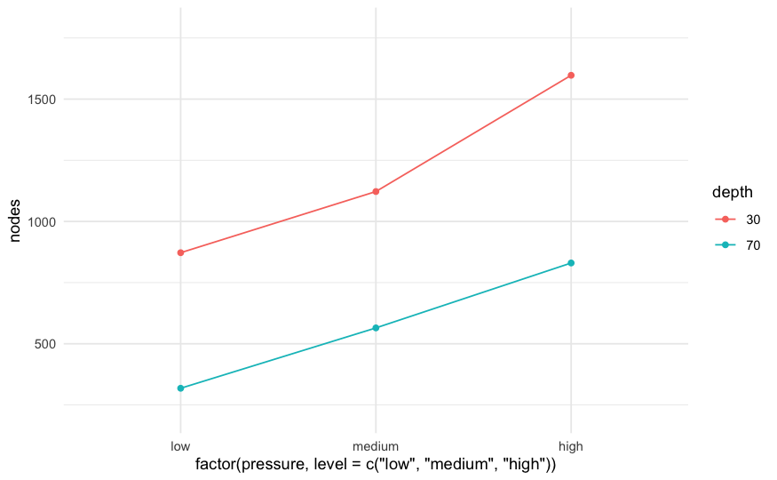

```r
ggplot(data = df, aes(x=factor(pressure, level = c("low", "medium", "high")), y=nodes, group=depth, colour=depth))+
  geom_line(stat = "summary") +
  geom_point(stat = "summary")+
  theme_minimal()
```

> Number of nodes shows positive effects of shallow water and increasing propagule pressure, with both factors having similar, but independent effects.

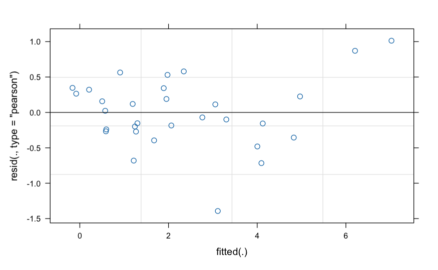

```r
#Can use aov or linear mixed models to do this
biomass.lmer <-lmer(biomass~depth + pressure + depth*pressure + (1|tank), REML=TRUE, df)
plot(biomass.lmer)
```

```r
summary(biomass.lmer, ddf="Kenward-Roger")
```

```
Linear mixed model fit by REML. t-tests use Kenward-Roger's method ['lmerModLmerTest']
Formula: biomass ~ depth + pressure + depth * pressure + (1 | tank)
   Data: df

REML criterion at convergence: 86

Scaled residuals:
     Min       1Q   Median       3Q      Max
-2.14121 -0.39993 -0.03638  0.47193  1.55739

Random effects:
 Groups   Name        Variance Std.Dev.
 tank     (Intercept) 1.6417   1.2813
 Residual             0.4231   0.6505
Number of obs: 30, groups:  tank, 10

Fixed effects:
                 Estimate Std. Error      df t value Pr(>|t|)
(Intercept)        2.2914     0.4222  8.0000   5.427 0.000626 ***
depth1             1.0884     0.4222  8.0000   2.578 0.032732 *
pressure1          1.1995     0.1679 16.0000   7.142 2.34e-06 ***
pressure2         -0.9422     0.1679 16.0000  -5.610 3.91e-05 ***
depth1:pressure1   0.5023     0.1679 16.0000   2.991 0.008639 **
depth1:pressure2  -0.2588     0.1679 16.0000  -1.541 0.142915
---
Signif. codes:  0 ‘***’ 0.001 ‘**’ 0.01 ‘*’ 0.05 ‘.’ 0.1 ‘ ’ 1

Correlation of Fixed Effects:
            (Intr) depth1 prssr1 prssr2 dpt1:1
depth1       0.000
pressure1    0.000  0.000
pressure2    0.000  0.000 -0.500
dpth1:prss1  0.000  0.000  0.000  0.000
dpth1:prss2  0.000  0.000  0.000  0.000 -0.500
```

```r
anova (biomass.lmer, ddf="Kenward-Roger")
```

```
Type III Analysis of Variance Table with Kenward-Roger's method
                Sum Sq Mean Sq NumDF DenDF F value    Pr(>F)
depth           2.8113  2.8113     1     8  6.6447   0.03273 *
pressure       23.9280 11.9640     2    16 28.2778 5.592e-06 ***
depth:pressure  3.7862  1.8931     2    16  4.4745   0.02861 *
---
Signif. codes:  0 ‘***’ 0.001 ‘**’ 0.01 ‘*’ 0.05 ‘.’ 0.1 ‘ ’ 1
```

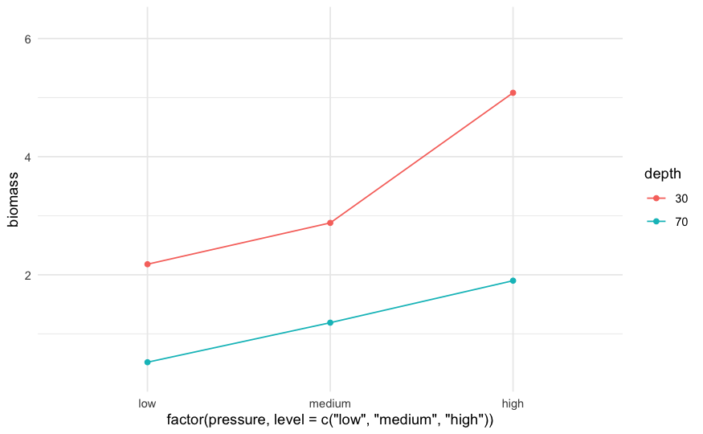

```r
ggplot(data = df, aes(x=factor(pressure, level = c("low", "medium", "high")), y=biomass, group=depth, colour=depth))+
  geom_line(stat = "summary") +
  geom_point(stat = "summary")+
  theme_minimal()
```

> For biomass, propagule pressure effects vary with depth. Not a large change, but overall increase in biomass with pressure, more biomass in shallow water, but biomass in shallow water at high propagule pressure is much higher than expected.

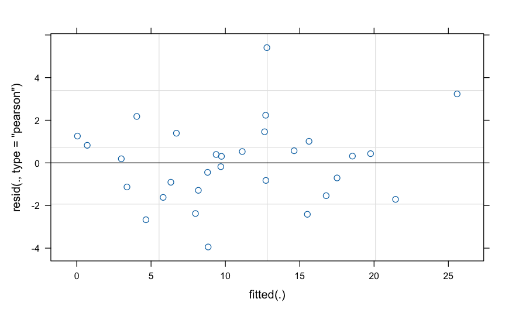

```r
#Can use aov or linear mixed models to do this
slength.lmer <-lmer(slength~depth + pressure + depth*pressure + (1|tank), REML=TRUE, df)
plot(slength.lmer)
```

```r
summary(slength.lmer, ddf="Kenward-Roger")
```

```
Linear mixed model fit by REML. t-tests use Kenward-Roger's method ['lmerModLmerTest']
Formula: slength ~ depth + pressure + depth * pressure + (1 | tank)
   Data: df

REML criterion at convergence: 148.8

Scaled residuals:
     Min       1Q   Median       3Q      Max
-1.57618 -0.49869  0.09962  0.38553  2.16020

Random effects:
 Groups   Name        Variance Std.Dev.
 tank     (Intercept) 18.960   4.354
 Residual              6.264   2.503
Number of obs: 30, groups:  tank, 10

Fixed effects:
                 Estimate Std. Error       df t value Pr(>|t|)
(Intercept)      10.82310    1.45081  8.00000   7.460 7.20e-05 ***
depth1            3.44348    1.45081  8.00000   2.373    0.045 *
pressure1         4.59470    0.64621 16.00000   7.110 2.47e-06 ***
pressure2        -3.87776    0.64621 16.00000  -6.001 1.85e-05 ***
depth1:pressure1  0.28223    0.64621 16.00000   0.437    0.668
depth1:pressure2 -0.05518    0.64621 16.00000  -0.085    0.933
---
Signif. codes:  0 ‘***’ 0.001 ‘**’ 0.01 ‘*’ 0.05 ‘.’ 0.1 ‘ ’ 1

Correlation of Fixed Effects:
            (Intr) depth1 prssr1 prssr2 dpt1:1
depth1       0.000
pressure1    0.000  0.000
pressure2    0.000  0.000 -0.500
dpth1:prss1  0.000  0.000  0.000  0.000
dpth1:prss2  0.000  0.000  0.000  0.000 -0.500
```

```r
anova (slength.lmer, ddf="Kenward-Roger")
```

```
Type III Analysis of Variance Table with Kenward-Roger's method
               Sum Sq Mean Sq NumDF DenDF F value    Pr(>F)
depth           35.29  35.287     1     8  5.6335     0.045 *
pressure       366.62 183.311     2    16 29.2652 4.511e-06 ***
depth:pressure   1.34   0.671     2    16  0.1072     0.899
---
Signif. codes:  0 ‘***’ 0.001 ‘**’ 0.01 ‘*’ 0.05 ‘.’ 0.1 ‘ ’ 1
```

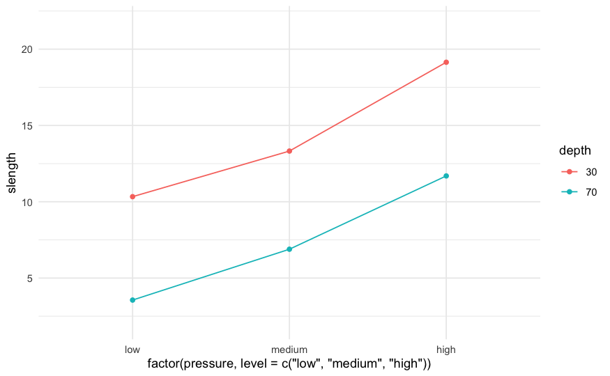

```r
ggplot(data = df, aes(x=factor(pressure, level = c("low", "medium", "high")), y=slength, group=depth, colour=depth))+
  geom_line(stat = "summary") +
  geom_point(stat = "summary")+
  theme_minimal()
```

> Again, clear effects of propagule pressure and depth. Four-fold difference in propagule pressure has a bit more effect than depth does.

## B.

The data are available from [dryad](https://datadryad.org/stash/dataset/doi:10.5061/dryad.4ht86). The data for this example are in *GrowSplitPlot.xlsx,* but it needs quite a bit of work for us to work with it in R. Our tidied version is here

Load the data and have a quick look. The variable names should be clear

```r
df <- read.csv("data/seitz.csv")
df$Plot <-as.factor(df$Plot)
head(df,10)
```

|  | Habitat | Plot | Growth | Predation |
| --- | --- | --- | --- | --- |
| 1 | Mud | 1 | 0.7 | Exclusion |
| 2 | Mud | 1 | 0.7 | Exclusion |
| 3 | Mud | 1 | 0.2 | Exclusion |
| 4 | Mud | 1 | 1.1 | Exclusion |
| 5 | Mud | 1 | 0.9 | Exclusion |
| 6 | Mud | 1 | 0.3 | Exclusion |
| 7 | Mud | 1 | 0.0 | Exclusion |
| 8 | Mud | 2 | 0.1 | Exclusion |
| 9 | Mud | 2 | 0.6 | Exclusion |
| 10 | Mud | 2 | 0.1 | Exclusion |

```r
set_sum_contrasts()
```

```
setting contr.sum globally: options(contrasts=c('contr.sum', 'contr.poly'))
```

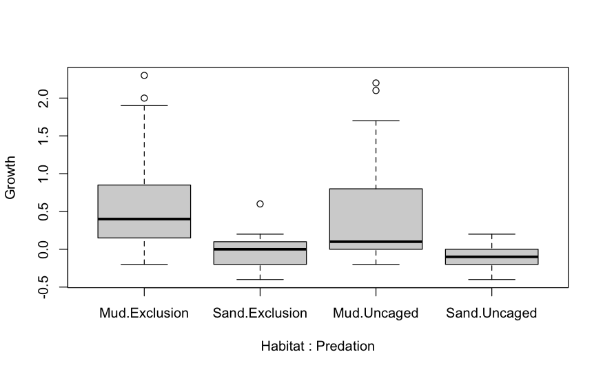

```r
boxplot(Growth~Habitat*Predation, df)
```

> Some hint of skew and associated differences in variance, but not dramatic